# Assignment 3: Problem 2.24

Tan Hong Ming A0053974W

September 16, 2017

#### Consider a simplified learning scenario. Assume that the input dimension is one. Assume that the input variable $x$ is uniformly distributed in the interval $[-1,1]$. The data set consists of $2$ points ${x_1,x_2}$ and assume that the target function is $f(x)=x^2$. Thus, the full data set is $\mathcal{D}={(x_1,x_1^2),(x_2,x_2^2)}$. The learning algorithm returns the line fitting these two points as $g$ ($\mathcal{H}$ consists of functions of the form $h(x) = ax+b$). We are interested in the test performance ($\mathbb{E}[E_{out}]$) of our learning system with respect to the squared error measure, the bias and the var.

#### (a) Give the analytic expression for the average function $\bar{g}(x)$.

Given $X_i\sim \mathcal{Uniform}[-1,1]$ and $\bar{g}(x)=\mathbb{E}_\mathcal{D}[Ax+B]$, we have $A=\frac{X_1^2-X_2^2}{X_1-X_2}=X_1+X_2$. Since the equation of a straight line is given by $(X_1+X_2)(x-X_1)+X_1^2=(X_1+X_2)x-X_1X_2$. Hence $B=-X_1X_2$. Knowing $\mathbb{E}_\mathcal{D}[X_i]=0$, we get

$$\begin{align*}
\bar{g}(x)&=\mathbb{E}_\mathcal{D}[(X_1+X_2)x-X_1X_2]\\
&=(\mathbb{E}_\mathcal{D}[X_1]+\mathbb{E}_\mathcal{D}[X_2])x-\mathbb{E}_\mathcal{D}[X_1]\mathbb{E}_\mathcal{D}[X_2]\\
&=0
\end{align*}$$

```r
#load libraries
library('ggplot2');
#generating data
N=1000;
set.seed(12345);
g = data.frame(x1=runif(N,min = -1,max = 1),x2=runif(N,min = -1, max=1));
g$y1 = g$x1^2;
g$y2 = g$x2^2;

#view first few lines of dataframe
head(g);
```

```
##            x1         x2          y1         y2
## 1  0.44180779 -0.8444866 0.195194126 0.71315761
## 2  0.75154639  0.6874273 0.564821971 0.47255629
## 3  0.52196466 -0.9863726 0.272447103 0.97293097
## 4  0.77224913 -0.2976316 0.596368722 0.08858456
## 5 -0.08703808  0.3721221 0.007575627 0.13847483
## 6 -0.66725643 -0.4918270 0.445231143 0.24189381
```

```r
#finding equation of line
g$a = (g$y1-g$y2)/(g$x1-g$x2);
g$b = g$a*(-g$x1)+g$y1;

#view first few lines of dataframe after finding slopes and intercepts
head(g);
```

```
##            x1         x2          y1         y2          a           b
## 1  0.44180779 -0.8444866 0.195194126 0.71315761 -0.4026788  0.37310076
## 2  0.75154639  0.6874273 0.564821971 0.47255629  1.4389737 -0.51663350
## 3  0.52196466 -0.9863726 0.272447103 0.97293097 -0.4644080  0.51485165
## 4  0.77224913 -0.2976316 0.596368722 0.08858456  0.4746175  0.22984574
## 5 -0.08703808  0.3721221 0.007575627 0.13847483  0.2850840  0.03238879
## 6 -0.66725643 -0.4918270 0.445231143 0.24189381 -1.1590834 -0.32817474
```

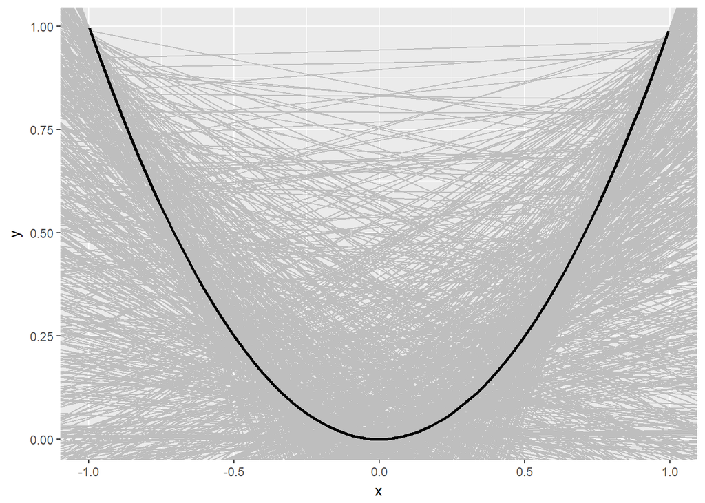

```r
#plotting lines
ggplot(data = g, aes(x1,y1)) + xlab('x') + ylab('y') +
  geom_abline(aes(slope = a, intercept = b), colour = "gray") +
  stat_function(fun=function(x)x^2, size = 1);
```

```r
#finding gbar
g$aBar = mean(g$a);
g$bBar = mean(g$b);

#finding sd for each point
for(i in 1:N) {
  g$sd[i]=sd(g$x1[i]*g$a+g$b);
  g$mean[i]=mean(g$x1[i]*g$a+g$b);
}

#finding +sd and -sd for each point

g$up=g$mean+g$sd;
g$low=g$mean-g$sd;

head(g);
```

```
##            x1         x2          y1         y2          a           b
## 1  0.44180779 -0.8444866 0.195194126 0.71315761 -0.4026788  0.37310076
## 2  0.75154639  0.6874273 0.564821971 0.47255629  1.4389737 -0.51663350
## 3  0.52196466 -0.9863726 0.272447103 0.97293097 -0.4644080  0.51485165
## 4  0.77224913 -0.2976316 0.596368722 0.08858456  0.4746175  0.22984574
## 5 -0.08703808  0.3721221 0.007575627 0.13847483  0.2850840  0.03238879
## 6 -0.66725643 -0.4918270 0.445231143 0.24189381 -1.1590834 -0.32817474
##         aBar        bBar        sd        mean        up        low
## 1 0.05526614 -0.00921451 0.4602631  0.01520250 0.4754656 -0.4450606
## 2 0.05526614 -0.00921451 0.6644639  0.03232056 0.6967844 -0.6321433
## 3 0.05526614 -0.00921451 0.5087750  0.01963246 0.5284075 -0.4891426
## 4 0.05526614 -0.00921451 0.6793251  0.03346472 0.7127898 -0.6458604
## 5 0.05526614 -0.00921451 0.3451982 -0.01402477 0.3311734 -0.3592229
## 6 0.05526614 -0.00921451 0.6723059 -0.04609120 0.6262147 -0.7183971
```

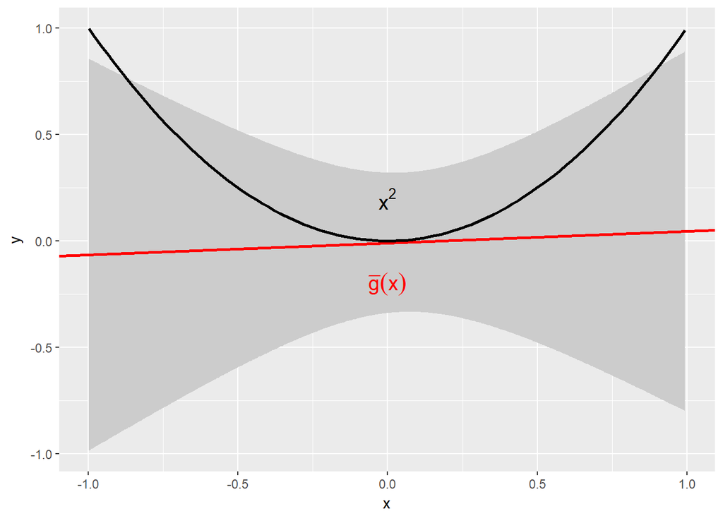

```r
#plot gBar+-sd
ggplot(data = g, aes(x1,up,low) ) +
  xlab('x') +ylab('y') + geom_ribbon(aes(ymin=low,ymax=up),fill='grey80') +
  geom_abline(aes(slope = mean(a), intercept = mean(b)), colour='red', size = 1) +
  stat_function(fun=function(x)x^2, size = 1,) +
  annotate("text",x=0,y=0.2, label='x ^ 2', parse=TRUE,size=5) +
  annotate("text",x=0,y=-0.2, label='bar(g)(x)', colour='red', parse=TRUE,size=5);
```

#### (d) Compute analytically what $\mathbb{E}[E_{out}]$, bias and var should be.